# Tropical River

Xingchen LIU

2026-01-07

Référence de l’article

Li et al., Bacterial Community Composition and Function of Tropical River Ecosystem along the Nandu River on Hainan Island, China, International Journal of Environmental Research and Public Health, 2023

Introduction Les écosystèmes fluviaux tropicaux sont soumis depuis longtemps à de fortes pressions liées aux activités humaines, telles que l’urbanisation, les pratiques agricoles et les apports de polluants. Ces pressions peuvent entraîner des modifications de la composition des communautés bactériennes, des changements de la diversité microbienne, ainsi que des altérations des fonctions écologiques, notamment les cycles des nutriments et la dégradation des polluants.

Cependant, dans le bassin versant de la rivière Nandu, sur l’île de Hainan (Chine), la structure des communautés bactériennes, le rôle des facteurs environnementaux dans leur organisation, ainsi que les fonctions potentielles des bactéries n’avaient jusqu’à présent pas fait l’objet d’une étude systématique.

Dans ce contexte, la présente étude s’articule autour des questions scientifiques suivantes :

1.Existe-t-il des différences dans la composition des communautés bactériennes entre les différents tronçons de la rivière Nandu (amont, moyen et aval) et le réservoir de Songtao ? 2.Quels facteurs environnementaux, tels que l’oxygène dissous et les nutriments azotés, exercent une influence significative sur la structure des communautés bactériennes ? 3.Quelles fonctions écologiques potentielles les communautés bactériennes de la rivière Nandu et du réservoir de Songtao sont-elles susceptibles d’assurer ?

Matériels et Méthodes

```r
library(dada2); packageVersion("dada2")
```

```
## [1] '1.28.0'
```

```r
path <- "~/Dada2/Nord-est/Nord-est"
list.files(path)
```

```
##  [1] "alpha_diversity_indices.csv"
##  [2] "ena-file-download-read_run-PRJNA878943-fastq_ftp-20260107-1939.sh"
##  [3] "Fig2_pastel_readsPct.png"
##  [4] "Fig2_pastel.png"
##  [5] "Fig2_venn_ASV.png"
##  [6] "Figure2_venn_with_reads.png"
##  [7] "Figure2_venn.png"
##  [8] "Figure3_alpha_diversity.png"
##  [9] "Figure4_phylum_top10.png"
## [10] "Figure5_genus_ggplot.png"
## [11] "Figure5_genus_heatmap.png"
## [12] "Figure6_PCoA.png"
## [13] "Figure6B_NMDS.png"
## [14] "filtered"
## [15] "for_errors"
```

[output cut: 36 more lines]

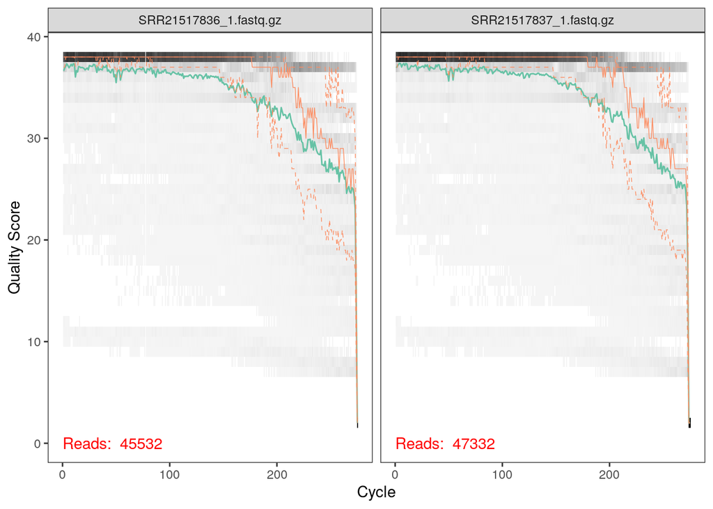

```r
fnFs <- sort(list.files(path, pattern="_1.fastq.gz", full.names = TRUE))
fnRs <- sort(list.files(path, pattern="_2.fastq.gz", full.names = TRUE))

sample.names <- sapply(strsplit(basename(fnFs), "_"), `[`, 1)
plotQualityProfile(fnFs[1:2])
```

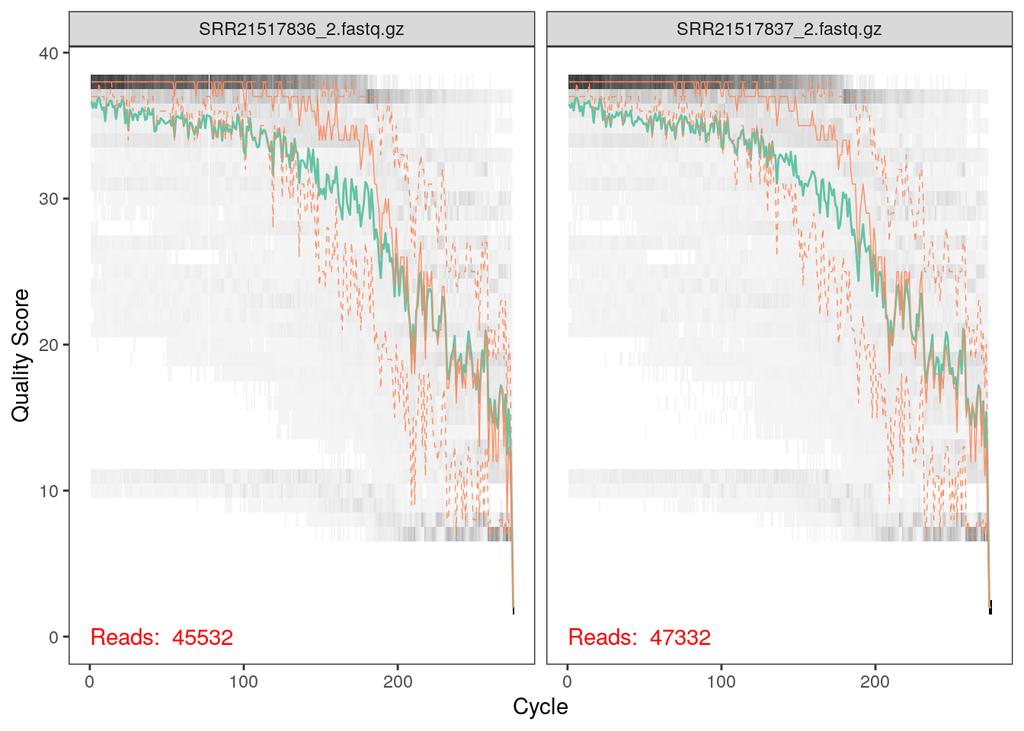

```r
plotQualityProfile(fnRs[1:2])
```

```r
filtFs <- file.path(path, "filtered", paste0(sample.names, "_1.fastq.gz"))
filtRs <- file.path(path, "filtered", paste0(sample.names, "_2.fastq.gz"))
names(filtFs) <- sample.names
names(filtRs) <- sample.names
out <- filterAndTrim(fnFs, filtFs, fnRs, filtRs, truncLen=c(260,220),
                     maxN=0, maxEE=c(2,2), truncQ=2, rm.phix=TRUE,
                     compress=TRUE, multithread=F)
head(out)
```

```
##                        reads.in reads.out
## SRR21517836_1.fastq.gz    45532     27511
## SRR21517837_1.fastq.gz    47332     28703
## SRR21517838_1.fastq.gz    46324     27420
## SRR21517839_1.fastq.gz    44601     28007
## SRR21517840_1.fastq.gz    42319     24186
## SRR21517841_1.fastq.gz    43093     27672
```

```r
errF <- learnErrors(filtFs, multithread=TRUE)
```

```
## 105314040 total bases in 405054 reads from 14 samples will be used for learning the error rates.
```

```r
errR <- learnErrors(filtRs, multithread=TRUE)
```

```
## 89111880 total bases in 405054 reads from 14 samples will be used for learning the error rates.
```

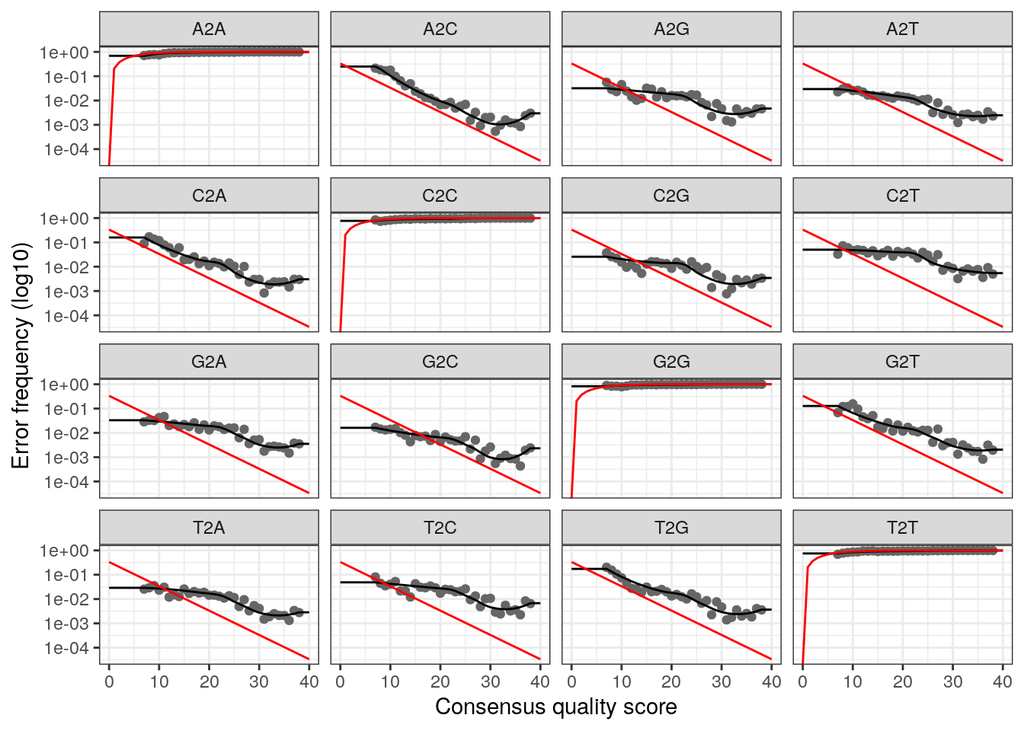

```r
plotErrors(errF, nominalQ=TRUE)
```

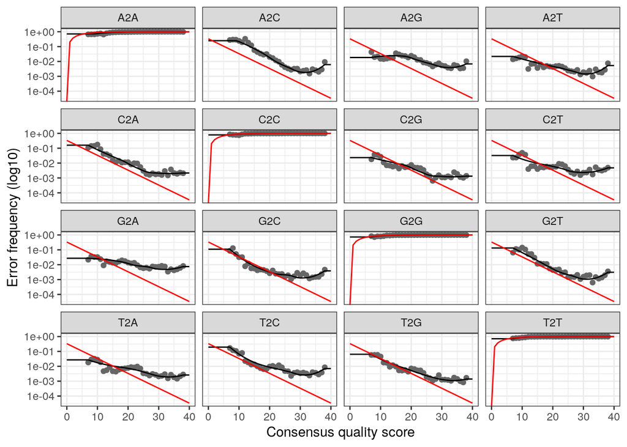

```r
plotErrors(errR, nominalQ=TRUE)
```

```r
dadaFs <- dada(filtFs, err=errF, multithread=TRUE)
```

```
## Sample 1 - 27511 reads in 6212 unique sequences.
## Sample 2 - 28703 reads in 7880 unique sequences.
## Sample 3 - 27420 reads in 9421 unique sequences.
## Sample 4 - 28007 reads in 9637 unique sequences.
## Sample 5 - 24186 reads in 7848 unique sequences.
## Sample 6 - 27672 reads in 8325 unique sequences.
## Sample 7 - 28650 reads in 8630 unique sequences.
## Sample 8 - 30241 reads in 10755 unique sequences.
## Sample 9 - 28994 reads in 7075 unique sequences.
## Sample 10 - 27635 reads in 8334 unique sequences.
## Sample 11 - 28937 reads in 8704 unique sequences.
## Sample 12 - 27562 reads in 6693 unique sequences.
## Sample 13 - 38193 reads in 13120 unique sequences.
## Sample 14 - 31343 reads in 11118 unique sequences.
```

```r
dadaRs <- dada(filtRs, err=errR, multithread=TRUE)
```

```
## Sample 1 - 27511 reads in 8669 unique sequences.
## Sample 2 - 28703 reads in 10182 unique sequences.
## Sample 3 - 27420 reads in 10905 unique sequences.
## Sample 4 - 28007 reads in 11077 unique sequences.
## Sample 5 - 24186 reads in 10224 unique sequences.
## Sample 6 - 27672 reads in 9195 unique sequences.
## Sample 7 - 28650 reads in 11412 unique sequences.
## Sample 8 - 30241 reads in 12427 unique sequences.
## Sample 9 - 28994 reads in 7851 unique sequences.
## Sample 10 - 27635 reads in 9347 unique sequences.
## Sample 11 - 28937 reads in 8762 unique sequences.
## Sample 12 - 27562 reads in 9249 unique sequences.
## Sample 13 - 38193 reads in 14636 unique sequences.
## Sample 14 - 31343 reads in 13112 unique sequences.
```

```r
dadaFs[[1]]
```

```
## dada-class: object describing DADA2 denoising results
## 415 sequence variants were inferred from 6212 input unique sequences.
## Key parameters: OMEGA_A = 1e-40, OMEGA_C = 1e-40, BAND_SIZE = 16
```

```r
mergers <- mergePairs(dadaFs, filtFs, dadaRs, filtRs, verbose=TRUE)
```

```
## 25237 paired-reads (in 376 unique pairings) successfully merged out of 26371 (in 875 pairings) input.
```

```
## 24923 paired-reads (in 427 unique pairings) successfully merged out of 26924 (in 1456 pairings) input.
```

```
## 22058 paired-reads (in 490 unique pairings) successfully merged out of 24337 (in 1603 pairings) input.
```

```
## 22661 paired-reads (in 443 unique pairings) successfully merged out of 24893 (in 1477 pairings) input.
```

```
## 19808 paired-reads (in 411 unique pairings) successfully merged out of 21478 (in 1001 pairings) input.
```

```
## 23294 paired-reads (in 338 unique pairings) successfully merged out of 25353 (in 1458 pairings) input.
```

```
## 24247 paired-reads (in 500 unique pairings) successfully merged out of 26450 (in 1447 pairings) input.
```

```
## 23970 paired-reads (in 511 unique pairings) successfully merged out of 26642 (in 1696 pairings) input.
```

```
## 25229 paired-reads (in 265 unique pairings) successfully merged out of 27239 (in 1041 pairings) input.
```

```
## 23024 paired-reads (in 360 unique pairings) successfully merged out of 25403 (in 1534 pairings) input.
```

```
## 24132 paired-reads (in 376 unique pairings) successfully merged out of 27036 (in 1804 pairings) input.
```

```
## 24861 paired-reads (in 405 unique pairings) successfully merged out of 26362 (in 1086 pairings) input.
```

```
## 30883 paired-reads (in 611 unique pairings) successfully merged out of 34951 (in 3082 pairings) input.
```

```
## 25038 paired-reads (in 539 unique pairings) successfully merged out of 28021 (in 2039 pairings) input.
```

```r
head(mergers[[1]])
```

```
##                                                                                                                                                                                                                                                                                                          …
## 1      TGGGGAATCTTGCGCAATGGGCGAAAGCCTGACGCAGCAACGCCGCGTGCGGGAAGAAGG…
## 2      TGGGGAATCTTGCGCAATGGGCGAAAGCCTGACGCAGCAACGCCGCGTGCGGGAAGAAGG…
## 3 TAGGGAATATTGGGCAATGGGCGCAAGCCTGACCCAGCGACGCCGCGTGAGGGATGAAGG…
## 4 TGGGGAATATTGGGCAATGGAGGAAACTCTGACCCAGCGACGCCGCGTGCGGGATGAAGG…
## 5    TGGGGAATTTTCCGCAATGGGCGAAAGCCTGACGGAGCAACGCCGCGTGAGGGATGAAGG…
## 6 TAGGGAATATTGGGCAATGGGCGAAAGCCTGACCCAGCGACGCCGCGTGAGGGATGAAGG…
##   abundance forward reverse nmatch nmismatch nindel prefer accept
## 1      2331       1       3     76         0      0      1   TRUE
## 2      2145       2       2     76         0      0      1   TRUE
## 3      1692       3       1     71         0      0      2   TRUE
## 4      1532       4       4     71         0      0      1   TRUE
## 5      1086       5       5     74         0      0      1   TRUE
## 6       958       6       1     71         0      0      2   TRUE
```

```r
seqtab <- makeSequenceTable(mergers)
dim(seqtab)
```

```
## [1]   14 2757
```

```r
table(nchar(getSequences(seqtab)))
```

```
##
## 373 374 375 376 385 399 400 401 403 404 405 406 407 408 409 410 411 412 413 414
##   2   1   1   1   1   1   1   1  19 338 143 172  61  29 276  13  10   4   1   1
## 415 416 417 418 419 420 421 422 423 424 425 426 427 428 429 430 431 432 451
##   3   5   6   1   4   1  11  13  62 383  31   3   3 123 881 144   5   1   1
```

```r
seqtab.nochim <- removeBimeraDenovo(seqtab, method="consensus", multithread=TRUE, verbose=TRUE)
```

```
## Identified 728 bimeras out of 2757 input sequences.
```

```r
dim(seqtab.nochim)
```

```
## [1]   14 2029
```

```r
sum(seqtab.nochim)/sum(seqtab)
```

```
## [1] 0.9683851
```

```r
getN <- function(x) sum(getUniques(x))
track <- cbind(out, sapply(dadaFs, getN), sapply(dadaRs, getN), sapply(mergers, getN), rowSums(seqtab.nochim))


colnames(track) <- c("input", "filtered", "denoisedF", "denoisedR", "merged", "nonchim")
rownames(track) <- sample.names
head(track)
```

```
##             input filtered denoisedF denoisedR merged nonchim
## SRR21517836 45532    27511     26685     26927  25237   24585
## SRR21517837 47332    28703     27479     27797  24923   24522
## SRR21517838 46324    27420     24997     25377  22058   21382
## SRR21517839 44601    28007     25447     26080  22661   22253
## SRR21517840 42319    24186     22032     22236  19808   19557
## SRR21517841 43093    27672     25854     26234  23294   22679
```

```r
taxa <- assignTaxonomy(seqtab.nochim, "~/tax/silva_nr_v132_train_set.fa.gz", multithread=TRUE)

taxa <- addSpecies(taxa, "~/tax/silva_species_assignment_v132.fa.gz")
```

```r
taxa.print <- taxa
rownames(taxa.print) <- NULL
head(taxa.print)
```

```
##      Kingdom    Phylum           Class                 Order
## [1,] "Bacteria" "Proteobacteria" "Gammaproteobacteria" "Pseudomonadales"
## [2,] "Bacteria" "Bacteroidetes"  "Bacteroidia"         "Cytophagales"
## [3,] "Bacteria" "Bacteroidetes"  "Bacteroidia"         "Chitinophagales"
## [4,] "Bacteria" "Actinobacteria" "Actinobacteria"      "Frankiales"
## [5,] "Bacteria" "Proteobacteria" "Gammaproteobacteria" "Betaproteobacteriales"
## [6,] "Bacteria" "Actinobacteria" "Actinobacteria"      "Frankiales"
##      Family             Genus               Species
## [1,] "Moraxellaceae"    "Acinetobacter"     NA
## [2,] "Spirosomaceae"    "Pseudarcicella"    NA
## [3,] "Chitinophagaceae" "Sediminibacterium" NA
## [4,] "Sporichthyaceae"  "hgcI_clade"        NA
## [5,] "Burkholderiaceae" "Limnohabitans"     NA
## [6,] "Sporichthyaceae"  "hgcI_clade"        NA
```

```r
library(phyloseq); packageVersion("phyloseq")
```

```
## [1] '1.44.0'
```

```r
library(Biostrings); packageVersion("Biostrings")
```

```
## [1] '2.68.1'
```

```r
library(ggplot2); packageVersion("ggplot2")
```

```
## [1] '3.4.3'
```

```r
theme_set(theme_bw())
```

```r
samples.out <- trimws(as.character(rownames(seqtab.nochim)))
meta <- read.csv("meta.csv", sep=";", stringsAsFactors = FALSE, check.names = FALSE)
meta$Run <- trimws(as.character(meta$Run))
meta$SampleID <- trimws(as.character(meta$SampleID))
meta$Group <- trimws(as.character(meta$Group))
stopifnot(all(samples.out %in% meta$Run))
samdf <- meta[match(samples.out, meta$Run), , drop = FALSE]
rownames(samdf) <- samdf$Run
samdf$Group <- factor(samdf$Group, levels = c("Lower","Middle","Upper","Reservoir"))
```

```r
ps <- phyloseq(otu_table(seqtab.nochim, taxa_are_rows=FALSE),
               sample_data(samdf),
               tax_table(taxa))
ps
```

```
## phyloseq-class experiment-level object
## otu_table()   OTU Table:         [ 2029 taxa and 14 samples ]
## sample_data() Sample Data:       [ 14 samples by 3 sample variables ]
## tax_table()   Taxonomy Table:    [ 2029 taxa by 7 taxonomic ranks ]
```

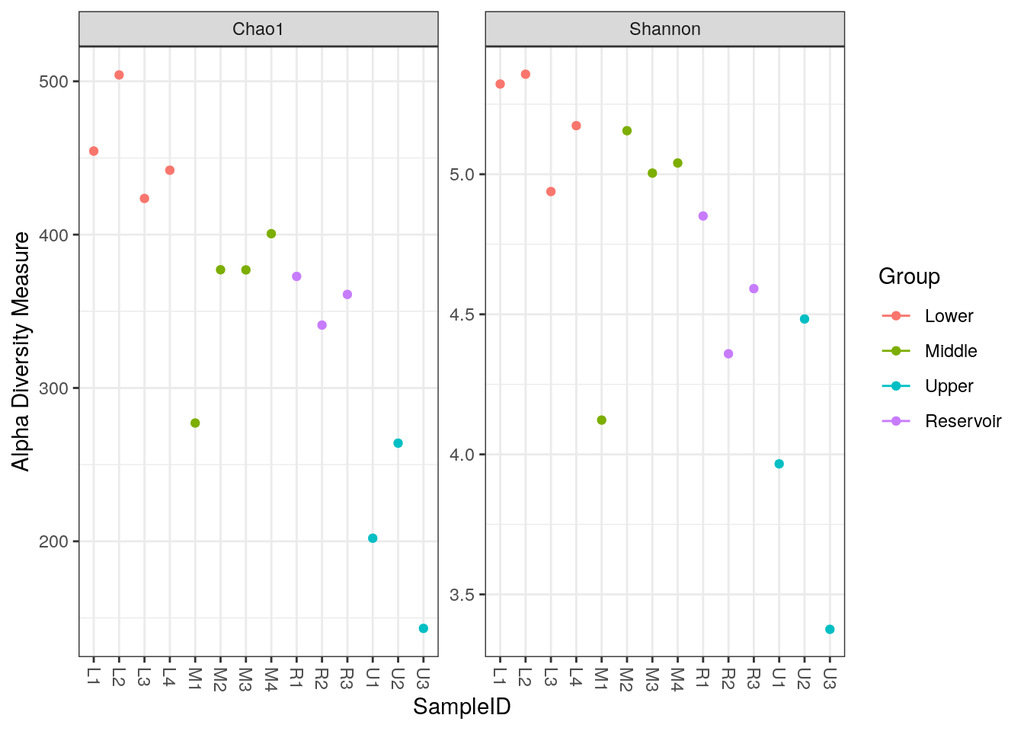

```r
plot_richness(ps, x="SampleID", measures=c("Chao1", "Shannon"), color="Group")
```

Les résultats montrent que le groupe Upper présente les valeurs les plus faibles pour les deux indices de diversité alpha. Pour l’indice de Chao1, la richesse spécifique du groupe Upper est nettement inférieure à celle des groupes Lower, Middle et Reservoir ; de même, pour l’indice de Shannon, le groupe Upper affiche les niveaux de diversité les plus bas, indiquant que sa communauté bactérienne se caractérise à la fois par un nombre réduit de taxons et par une faible homogénéité.

À l’inverse, le groupe Lower présente les niveaux de diversité alpha les plus élevés, tandis que les groupes Middle et Reservoir occupent une position intermédiaire, révélant un gradient de diversité croissant le long du cours d’eau, de l’amont vers l’aval.

```r
ps.prop <- transform_sample_counts(ps, function(otu) otu/sum(otu))
ord.nmds.bray <- ordinate(ps.prop, method="NMDS", distance="bray")
```

```
## *** Best solution repeated 7 times
```

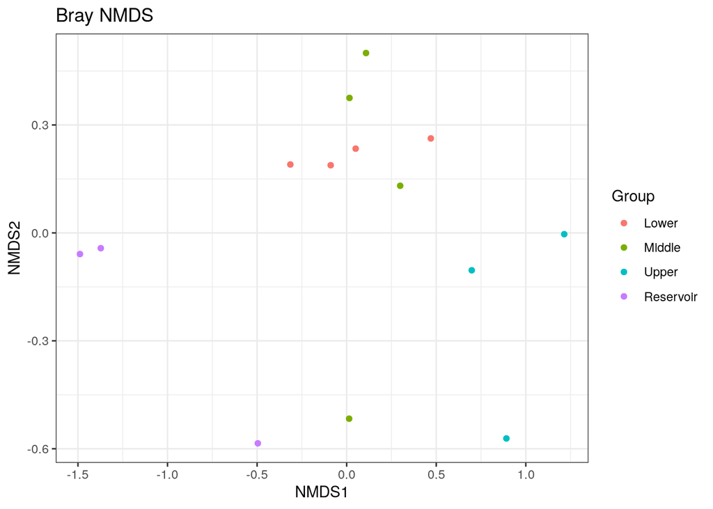

```r
plot_ordination(ps.prop,
                ord.nmds.bray,
                color="Group",
                title="Bray NMDS")
```

L’ordination NMDS met en évidence une séparation globale des communautés en fonction de leur position le long du continuum fleuve–réservoir.

Les échantillons du groupe Upper se distinguent nettement des autres groupes dans l’espace d’ordination, indiquant une composition bactérienne spécifique en amont du fleuve. À l’inverse, les groupes Lower et Middle présentent une plus grande proximité les uns avec les autres, suggérant des communautés bactériennes relativement similaires dans les sections intermédiaires et aval du cours d’eau.

Les échantillons du réservoir forment également un ensemble distinct, séparé des sites fluviaux, ce qui reflète l’influence des conditions environnementales propres aux milieux lentiques sur la structure des communautés microbiennes.

Ces résultats sont cohérents avec ceux rapportés dans l’étude originale, qui montrait une différenciation significative des communautés bactériennes entre les sections amont, aval et le réservoir, confirmant l’effet marqué de la variabilité spatiale sur la diversité bêta le long du continuum fleuve–réservoir.

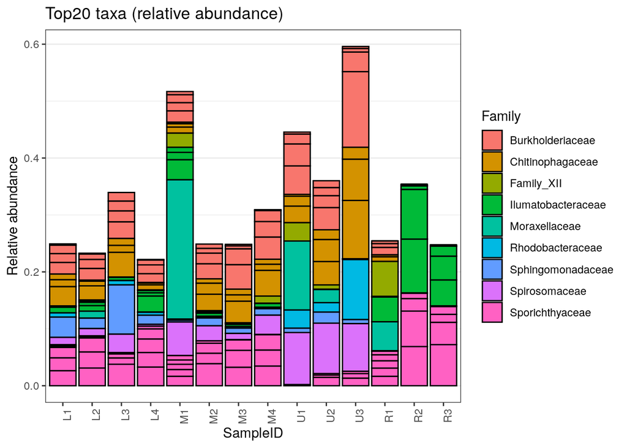

```r
top20 <- names(sort(taxa_sums(ps), decreasing = TRUE))[1:20]
ps.top20 <- transform_sample_counts(ps, function(x) x / sum(x))
ps.top20 <- prune_taxa(top20, ps.top20)
sample_data(ps.top20)$Group <- factor(
  sample_data(ps.top20)$Group,
  levels = c("Lower", "Middle", "Upper", "Reservoir")
)
sd <- data.frame(sample_data(ps.top20))
sd <- sd[order(sd$Group, sd$SampleID), , drop = FALSE]
sample_order <- sd$SampleID
sample_data(ps.top20)$SampleID <- factor(
  sample_data(ps.top20)$SampleID,
  levels = sample_order
)
p_top20_family <- plot_bar(ps.top20, x = "SampleID", fill = "Family") +
  theme_bw() +
  theme(
    axis.text.x = element_text(angle = 90, hjust = 1),
    panel.grid.major.x = element_blank()
  ) +
  labs(
    x = "SampleID",
    y = "Relative abundance",
    title = "Top20 taxa (relative abundance)"
  )

p_top20_family
```

La représentation des vingt taxons les plus abondants au niveau famille met en évidence une forte variabilité entre sites, indiquant que l’effet “station” contribue de manière importante à la structuration des communautés à ce niveau taxonomique. Des tendances de différenciation entre les groupes spatiaux (Lower, Middle, Upper et Reservoir) sont néanmoins perceptibles, mais l’hétérogénéité intra-groupe demeure marquée, certains sites d’un même groupe présentant des variations importantes d’abondance relative pour plusieurs familles dominantes. Ainsi, ce graphique constitue surtout une description qualitative des taxons dominants ; pour une comparaison spatiale plus directement comparable à l’étude originale, il est préférable de compléter l’analyse par des représentations aux niveaux phylum et Genus, telles que celles utilisées dans les Figures correspondantes de l’article.

```r
library(forcats)

cat("=== Diagnosing meta table ===\n")
```

```
## === Diagnosing meta table ===
```

```r
print(head(meta, 10))
```

```
##    SampleID  Group         Run
## 1        L1  Lower SRR21517849
## 2        L2  Lower SRR21517848
## 3        L3  Lower SRR21517843
## 4        L4  Lower SRR21517842
## 5        M1 Middle SRR21517841
## 6        M2 Middle SRR21517840
## 7        M3 Middle SRR21517839
## 8        M4 Middle SRR21517838
## 9        U1  Upper SRR21517846
## 10       U2  Upper SRR21517845
```

```r
cat("\nColumns in meta:", colnames(meta), "\n")
```

```
##
## Columns in meta: SampleID Group Run
```

```r
cat("Number of rows in meta:", nrow(meta), "\n")
```

```
## Number of rows in meta: 14
```

```r
cat("\n=== Diagnosing seqtab.nochim ===\n")
```

```
##
## === Diagnosing seqtab.nochim ===
```

```r
cat("Row names of seqtab.nochim (first 5):", head(rownames(seqtab.nochim), 5), "\n")
```

```
## Row names of seqtab.nochim (first 5): SRR21517836 SRR21517837 SRR21517838 SRR21517839 SRR21517840
```

```r
cat("Number of rows in seqtab.nochim:", nrow(seqtab.nochim), "\n")
```

```
## Number of rows in seqtab.nochim: 14
```

```r
cat("\n=== Key diagnostics ===\n")
```

```
##
## === Key diagnostics ===
```

```r
cat("meta$Run (first 5):", head(meta$Run, 5), "\n")
```

```
## meta$Run (first 5): SRR21517849 SRR21517848 SRR21517843 SRR21517842 SRR21517841
```

```r
cat("meta$SampleID (first 5):", head(meta$SampleID, 5), "\n")
```

```
## meta$SampleID (first 5): L1 L2 L3 L4 M1
```

```r
cat("Row names of seqtab.nochim:", head(rownames(seqtab.nochim), 5), "\n")
```

```
## Row names of seqtab.nochim: SRR21517836 SRR21517837 SRR21517838 SRR21517839 SRR21517840
```

```r
## Detect Phylum column
if ("Phylum" %in% colnames(taxa)) {
  phylum_col <- "Phylum"
} else if ("phylum" %in% colnames(taxa)) {
  phylum_col <- "phylum"
} else {
  stop("Phylum column not found in taxa table")
}


## Long-format ASV table
df_long <- as.data.frame(seqtab.nochim)
df_long$Run_ID <- rownames(df_long)
rownames(df_long) <- NULL

df_long <- tidyr::pivot_longer(
  df_long,
  cols = -Run_ID,
  names_to = "ASV",
  values_to = "Reads"
)

df_long <- df_long[df_long$Reads > 0, ]


## Taxonomy table
tax_df <- as.data.frame(taxa)
tax_df$ASV <- rownames(tax_df)
rownames(tax_df) <- NULL

tax_df <- tax_df[, c("ASV", phylum_col)]
colnames(tax_df)[2] <- "Phylum"
tax_df$Phylum <- as.character(tax_df$Phylum)


## Join taxonomy
df_long <- merge(
  df_long,
  tax_df,
  by = "ASV",
  all.x = TRUE
)

df_long$Phylum[
  is.na(df_long$Phylum) |
    df_long$Phylum == "" |
    df_long$Phylum == "NA"
] <- "Unclassified"


## Summarise to phylum level
df_phylum <- aggregate(
  Reads ~ Run_ID + Phylum,
  data = df_long,
  sum
)

total_reads <- aggregate(
  Reads ~ Run_ID,
  data = df_phylum,
  sum
)

df_phylum <- merge(
  df_phylum,
  total_reads,
  by = "Run_ID",
  suffixes = c("", "_Total")
)

df_phylum$RelAbund <- df_phylum$Reads / df_phylum$Reads_Total
df_phylum$Reads_Total <- NULL


cat("\n=== Checking Run matching ===\n")
```

```
##
## === Checking Run matching ===
```

```r
cat(
  "Run_ID matching meta$Run:",
  sum(df_phylum$Run_ID %in% meta$Run),
  "/",
  length(unique(df_phylum$Run_ID)),
  "\n"
)
```

```
## Run_ID matching meta$Run: 238 / 14
```

```r
## Join metadata
if (sum(df_phylum$Run_ID %in% meta$Run) == 0) {

  colnames(df_phylum)[colnames(df_phylum) == "Run_ID"] <- "SampleID"

  df_phylum <- merge(
    df_phylum,
    meta[, c("SampleID", "Group")],
    by = "SampleID",
    all.x = TRUE
  )

} else {

  colnames(df_phylum)[colnames(df_phylum) == "Run_ID"] <- "Run"

  df_phylum <- merge(
    df_phylum,
    meta[, c("Run", "SampleID", "Group")],
    by = "Run",
    all.x = TRUE
  )
}

df_phylum$Group <- factor(
  df_phylum$Group,
  levels = c("Lower", "Middle", "Upper", "Reservoir")
)


cat("\n=== Join diagnostics ===\n")
```

```
##
## === Join diagnostics ===
```

```r
cat("NA in Group after join:", sum(is.na(df_phylum$Group)), "\n")
```

```
## NA in Group after join: 0
```

```r
cat("NA in SampleID after join:", sum(is.na(df_phylum$SampleID)), "\n")
```

```
## NA in SampleID after join: 0
```

```r
print(head(df_phylum, 8))
```

```
##           Run           Phylum Reads     RelAbund SampleID     Group
## 1 SRR21517836    Acidobacteria   131 0.0053284523       R2 Reservoir
## 2 SRR21517836       Chlamydiae   102 0.0041488713       R2 Reservoir
## 3 SRR21517836   Planctomycetes   152 0.0061826317       R2 Reservoir
## 4 SRR21517836  Verrucomicrobia   699 0.0284319707       R2 Reservoir
## 5 SRR21517836 Gemmatimonadetes     7 0.0002847265       R2 Reservoir
## 6 SRR21517836  Patescibacteria   142 0.0057758796       R2 Reservoir
## 7 SRR21517836      Chloroflexi   454 0.0184665446       R2 Reservoir
## 8 SRR21517836 Margulisbacteria    32 0.0013016067       R2 Reservoir
```

```r
## Top 10 phyla
tmp <- df_phylum[!is.na(df_phylum$Group), ]

mean_ab <- aggregate(
  RelAbund ~ Phylum,
  data = tmp,
  mean
)

mean_ab <- mean_ab[order(mean_ab$RelAbund, decreasing = TRUE), ]
top10_phylum <- head(mean_ab$Phylum, 10)

cat("\nTop 10 phyla (by mean relative abundance):\n")
```

```
##
## Top 10 phyla (by mean relative abundance):
```

```r
print(top10_phylum)
```

```
##  [1] "Proteobacteria"      "Actinobacteria"      "Bacteroidetes"
##  [4] "Cyanobacteria"       "Firmicutes"          "Deinococcus-Thermus"
##  [7] "Acidobacteria"       "Verrucomicrobia"     "Chloroflexi"
## [10] "Patescibacteria"
```

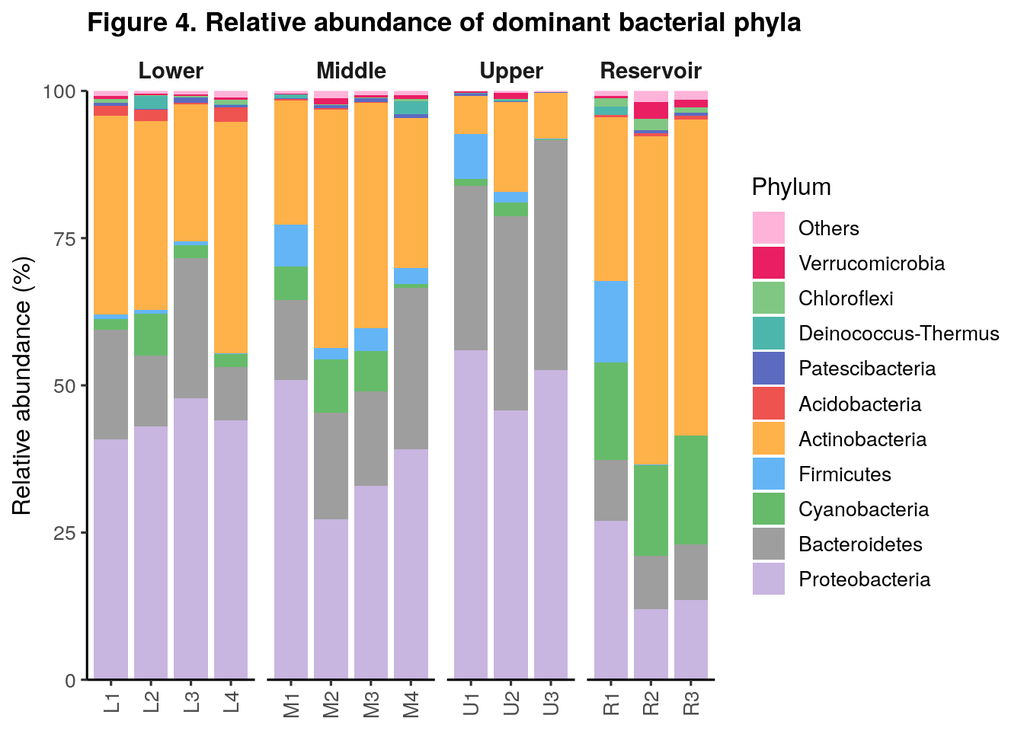

```r
## Collapse others
df_phylum2 <- tmp
df_phylum2$Phylum2 <- ifelse(
  df_phylum2$Phylum %in% top10_phylum,
  df_phylum2$Phylum,
  "Others"
)

df_phylum2 <- aggregate(
  RelAbund ~ SampleID + Group + Phylum2,
  data = df_phylum2,
  sum
)


## Order phyla
phylum_order <- c(
  "Others",
  "Verrucomicrobia",
  "Chloroflexi",
  "Deinococcus-Thermus",
  "Patescibacteria",
  "Acidobacteria",
  "Actinobacteria",
  "Firmicutes",
  "Cyanobacteria",
  "Bacteroidetes",
  "Proteobacteria"
)

phylum_order <- phylum_order[phylum_order %in% unique(df_phylum2$Phylum2)]
df_phylum2$Phylum2 <- factor(df_phylum2$Phylum2, levels = phylum_order)


## Sample order
sample_order <- unique(df_phylum2[, c("SampleID", "Group")])
sample_order <- sample_order[order(sample_order$Group, sample_order$SampleID), ]

df_phylum2$SampleID <- factor(
  df_phylum2$SampleID,
  levels = sample_order$SampleID
)

df_phylum2$Group <- factor(
  df_phylum2$Group,
  levels = c("Lower", "Middle", "Upper", "Reservoir")
)


## Colors
phylum_colors <- c(
  "Proteobacteria" = "#C8B5E0",
  "Actinobacteria" = "#FFB14A",
  "Bacteroidetes" = "#9E9E9E",
  "Cyanobacteria" = "#66BB6A",
  "Firmicutes" = "#64B5F6",
  "Acidobacteria" = "#EF5350",
  "Patescibacteria" = "#5C6BC0",
  "Deinococcus-Thermus" = "#4DB6AC",
  "Chloroflexi" = "#81C784",
  "Verrucomicrobia" = "#E91E63",
  "Others" = "#FFB3D9"
)


## Plot
fig4 <- ggplot(
  df_phylum2,
  aes(x = SampleID, y = RelAbund, fill = Phylum2)
) +
  geom_col(width = 0.85) +
  facet_grid(. ~ Group, scales = "free_x", space = "free_x") +
  scale_y_continuous(
    labels = function(x) x * 100,
    limits = c(0, 1),
    expand = c(0, 0)
  ) +
  scale_fill_manual(
    name = "Phylum",
    values = phylum_colors,
    breaks = phylum_order
  ) +
  labs(
    x = NULL,
    y = "Relative abundance (%)",
    title = "Figure 4. Relative abundance of dominant bacterial phyla"
  ) +
  theme_classic(base_size = 12) +
  theme(
    axis.text.x = element_text(angle = 90, vjust = 0.5, hjust = 1, size = 10),
    axis.text.y = element_text(size = 10),
    axis.title.y = element_text(size = 12),
    strip.background = element_blank(),
    strip.text = element_text(face = "bold", size = 11),
    legend.position = "right",
    legend.text = element_text(size = 10),
    plot.title = element_text(face = "bold", size = 13)
  )

fig4
```

```r
ggsave(
  "Figure4_phylum_top10.png",
  fig4,
  width = 13,
  height = 5,
  dpi = 300
)
```

Au niveau des phyla, les communautés bactériennes sont dominées par quelques groupes majeurs, principalement Proteobacteria, Bacteroidetes, Actinobacteria et Cyanobacteria, dont les abondances relatives présentent des tendances cohérentes entre les groupes spatiaux (Lower, Middle, Upper et Reservoir). Cette représentation permet de dégager clairement des patrons globaux et des gradients spatiaux le long du continuum fleuve–réservoir.

En revanche, la représentation basée sur les familles dominantes (Top20) révèle une variabilité beaucoup plus marquée entre les sites individuels. À ce niveau taxonomique plus fin, certaines familles peuvent être fortement dominantes dans un site donné tout en restant marginales dans d’autres sites appartenant au même groupe, ce qui souligne l’importance de l’effet station et des conditions locales.

Ainsi, tandis que l’analyse au niveau du phylum met en évidence des différences structurales générales entre les compartiments fluviaux et le réservoir, l’analyse au niveau de la famille reflète davantage l’hétérogénéité intra-groupe et la spécificité des sites d’échantillonnage. Ces deux approches sont donc complémentaires : la première est particulièrement adaptée à la comparaison spatiale à grande échelle, tandis que la seconde permet d’illustrer la diversité taxonomique fine et la complexité locale des communautés bactériennes.

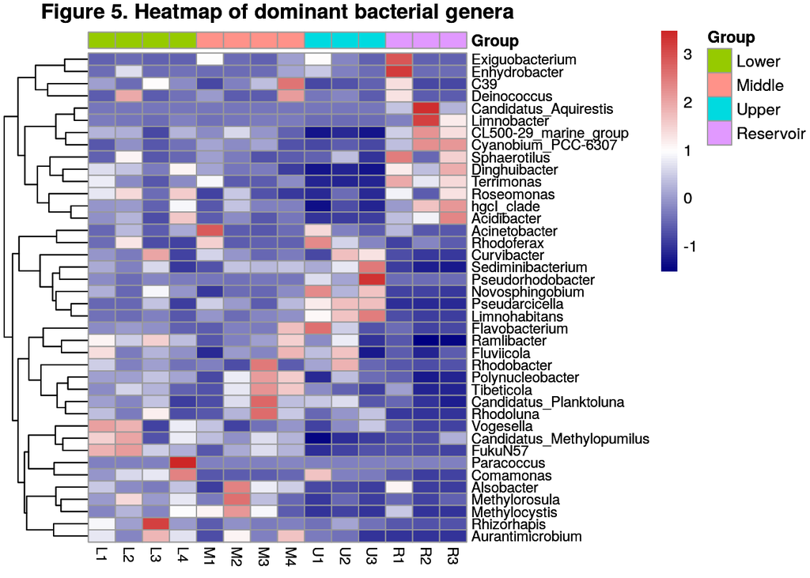

```r
library(phyloseq)
library(pheatmap)
ps.genus <- tax_glom(ps, taxrank = "Genus", NArm = TRUE)
ps.genus.rel <- transform_sample_counts(ps.genus, function(x) x / sum(x))
genus_sums <- taxa_sums(ps.genus.rel)
topN <- names(sort(genus_sums, decreasing = TRUE))[1:40]
ps.genus.top <- prune_taxa(topN, ps.genus.rel)
mat <- as.matrix(otu_table(ps.genus.top))
if (!taxa_are_rows(ps.genus.top)) {
  mat <- t(mat)
}
genus_names <- as.character(tax_table(ps.genus.top)[, "Genus"])
rownames(mat) <- genus_names
colnames(mat) <- sample_data(ps.genus.top)$SampleID
sd <- data.frame(sample_data(ps.genus.top))
sd$Group <- factor(
  sd$Group,
  levels = c("Lower", "Middle", "Upper", "Reservoir")
)
sd <- sd[order(sd$Group, sd$SampleID), , drop = FALSE]
mat <- mat[, sd$SampleID]
mat.z <- t(scale(t(mat)))
annotation_col <- data.frame(
  Group = sd$Group
)
rownames(annotation_col) <- sd$SampleID

fig5 <- pheatmap(
  mat.z,
  color = colorRampPalette(c("navy", "white", "firebrick3"))(100),
  cluster_rows = TRUE,
  cluster_cols = FALSE,
  annotation_col = annotation_col,
  fontsize_row = 9,
  fontsize_col = 9,
  main = "Figure 5. Heatmap of dominant bacterial genera"
)

fig5
```

Les échantillons sont ordonnés selon les groupes spatiaux (Lower, Middle, Upper et Reservoir), et les genres sont regroupés par classification hiérarchique. La carte met en évidence une structuration marquée des communautés bactériennes au niveau du genre le long du continuum fleuve–réservoir. Les groupes Lower et Middle présentent des profils génériques relativement similaires, tandis que le groupe Upper se distingue par une composition plus spécifique. Les échantillons du réservoir forment également un ensemble distinct par rapport aux sites fluviaux.

Discussion

Dans l’ensemble, ces résultats suggèrent que les gradients spatiaux et les différences environnementales le long du continuum fleuve–réservoir agissent conjointement pour façonner la structure des communautés bactériennes.